**This is part of Abdulrahman Alkhamees project work for [Data Analysis Nanodegree](https://sa.udacity.com/nanodegree)**

# Project: Investigate a TMDB Movie Dataset

## Introduction

We are going to explore together a TMDB movie dataset. This data set contains information about 10,000 movies collected from The Movie Database (TMDB), including user ratings and revenue. Personally, I never looked at the movies from a prespectve such as - what makes a movie achieve a high revenue? So, it is a good chance to figure it out and get an impression of the film industry.

We will first start with a general exploration of the data, to see trends . Then, we are going to research the following:

- Exlpore the things that affect the revenue, by looking at a couple of independent variables like budget, vote_average etc.
- Focus on the actors, and explore things like actors occurrence in the dataset and the presentage of actors who happened to be directors as well.

```python
# Here we import the libereies that we planning to use
import pandas as pd
import numpy as np
import matplotlib.pyplot as plt
%matplotlib inline
```

## Data Wrangling

```python
# Here we load the movies as Pandas dataframe
movies = pd.read_csv("tmdb-movies.csv")
```

```python
movies.head()
```

[output not shown]

```python
movies.describe()
```

|  | id | popularity | budget | revenue | runtime | vote_count | vote_average | release_year | budget_adj | revenue_adj |
| --- | --- | --- | --- | --- | --- | --- | --- | --- | --- | --- |
| count | 10866.000000 | 10866.000000 | 1.086600e+04 | 1.086600e+04 | 10866.000000 | 10866.000000 | 10866.000000 | 10866.000000 | 1.086600e+04 | 1.086600e+04 |
| mean | 66064.177434 | 0.646441 | 1.462570e+07 | 3.982332e+07 | 102.070863 | 217.389748 | 5.974922 | 2001.322658 | 1.755104e+07 | 5.136436e+07 |
| std | 92130.136561 | 1.000185 | 3.091321e+07 | 1.170035e+08 | 31.381405 | 575.619058 | 0.935142 | 12.812941 | 3.430616e+07 | 1.446325e+08 |
| min | 5.000000 | 0.000065 | 0.000000e+00 | 0.000000e+00 | 0.000000 | 10.000000 | 1.500000 | 1960.000000 | 0.000000e+00 | 0.000000e+00 |
| 25% | 10596.250000 | 0.207583 | 0.000000e+00 | 0.000000e+00 | 90.000000 | 17.000000 | 5.400000 | 1995.000000 | 0.000000e+00 | 0.000000e+00 |
| 50% | 20669.000000 | 0.383856 | 0.000000e+00 | 0.000000e+00 | 99.000000 | 38.000000 | 6.000000 | 2006.000000 | 0.000000e+00 | 0.000000e+00 |
| 75% | 75610.000000 | 0.713817 | 1.500000e+07 | 2.400000e+07 | 111.000000 | 145.750000 | 6.600000 | 2011.000000 | 2.085325e+07 | 3.369710e+07 |
| max | 417859.000000 | 32.985763 | 4.250000e+08 | 2.781506e+09 | 900.000000 | 9767.000000 | 9.200000 | 2015.000000 | 4.250000e+08 | 2.827124e+09 |

As can be seen here, budget & revenue have a lot of missing values. So, the insights that we gleaned from this data were obtained from just a sample of the dataset, and not from the entirety of it.

### Columns to drop

Here, I am dropping the columns that don't serve me any purpose in the analysis. For revenue and budget, I am taking the adjusted one. I've compared the two columns (the adjusted and the normal one) and noticed the following:

- Revenue numbers are from 2010 ( source: kaggle)
- Revenue adjusted value is greater than the original revenue value the following years
  - 1977
  - 2009
- Revenue adjusted value is lesser than the original revenue value for the following years
  - 2014
  - 2015
- Revenue adjusted value is equal to the original revenue value (revenue column) for the following:
  - 2010 -This tells us that the data was collected in 2010.

So I decided to use the adjusted values and drop the orginal one

```python
# putting all columns that I wanted to drop in list
c_to_drop = ['homepage','budget', 'revenue', 'id', 'imdb_id', 'overview', 'tagline' ]
movies.drop(c_to_drop, 1, inplace=True)
```

```python
#renameing columns
movies.rename(inplace=True, columns=({'revenue_adj': 'revenue'}))
movies.rename(inplace=True, columns=({'budget_adj': 'budget'}))
```

Next, we drop duplicated data. Let's first examine the shape

```python
movies.shape
```

```
(10866, 14)
```

```python
movies = movies.drop_duplicates()
```

It is interesting to see that only one record is deduplicated

```python
movies.shape
```

```
(10865, 14)
```

The next step is to check out the Null values. Having a null value makes things difficult when we want to apply a function to an entire series. Therefore, we will first check the number of Null Values present before we fill them with the appropriate value

```python
movies.isnull().sum()
```

[output not shown]

```python
movies.dtypes
```

```
popularity              float64
original_title           object
cast                     object
director                 object
keywords                 object
runtime                   int64
genres                   object
production_companies     object
release_date             object
vote_count                int64
vote_average            float64
release_year              int64
budget                  float64
revenue                 float64
dtype: object
```

```python
# this is for missing values
movies = movies.fillna("NaN")
```

```python
movies = movies.replace(0, np.NaN)
```

The reason I replaced the value 0 with NaN is because, sometimes, a value such as 0 will affect my result. This can affect the number of movies we have where the revenue is less than the budget. In this case, if the revenue is "0," which is missing the actual value, I will get a wrong value.

### Creating a new dataframe for Actors

I wanted to focus a little more and get insights on the actors in this dataset. However, since the current shape of the dataframe doesn't allow me to answer my questions, we are going to create a new dataframe that's going to be used later on to answer any questions related to the casts of the movies.

#### Creating a clean casts list

```python
# We are taking cast column to list, this step deosn't involve any cleaning, just applying map to each item
# Cleainig inspired by this post https://goo.gl/qc6xXf
casts_raw = list(map(str,(movies['cast'])))
actors = []
for i in casts_raw:
    split_cast = list(map(str, i.split('|')))
    for j in split_cast:
        actors.append(j)
```

#### Creating a clean directors list

```python
directors_raw = list(map(str,(movies['director'])))
directors = []
for i in directors_raw:
    split_d = list(map(str, i.split('|')))
    for j in split_d:
        directors.append(j)
```

#### Create a list of casts who directed movies!

```python
# List that put 1 for casts who are directors and 0 for non-directors
cast_director = []
for i in actors:
    if i in directors:
        cast_director.append(1)
    else:
        cast_director.append(0)
```

```python
# creating a new dataframe from the lists tha we just created - I am sure this is not the perfect way
actors = pd.DataFrame(list(zip(actors,cast_director)))
```

```python
actors.head()
```

|  | 0 | 1 |
| --- | --- | --- |
| 0 | Chris Pratt | 0 |
| 1 | Bryce Dallas Howard | 1 |
| 2 | Irrfan Khan | 0 |
| 3 | Vincent D'Onofrio | 0 |
| 4 | Nick Robinson | 0 |

```python
# renaming columns (there should be a better way :D
actors.rename(inplace=True, columns=({0: 'actors'}))
actors.rename(inplace=True, columns=({1: 'director'}))
```

```python
actors.head()
```

|  | actors | director |
| --- | --- | --- |
| 0 | Chris Pratt | 0 |
| 1 | Bryce Dallas Howard | 1 |
| 2 | Irrfan Khan | 0 |
| 3 | Vincent D'Onofrio | 0 |
| 4 | Nick Robinson | 0 |

New column to tell how many times an actor appeared in this dataset

```python
# New column to tell how many times an actor appeared in this dataset
actors['occurrence'] = actors.groupby(['actors']).transform('count')
```

```python
actors.head()
```

|  | actors | director | occurrence |
| --- | --- | --- | --- |
| 0 | Chris Pratt | 0 | 10 |
| 1 | Bryce Dallas Howard | 1 | 7 |
| 2 | Irrfan Khan | 0 | 6 |
| 3 | Vincent D'Onofrio | 0 | 24 |
| 4 | Nick Robinson | 0 | 5 |

Finally, in order to obtain a clear dataframe, the duplicates are removed.

```python
actors.shape
```

```
(52649, 3)
```

```python
actors = actors.drop_duplicates()
```

```python
actors.shape
```

```
(19027, 3)
```

## Browsing the dataset

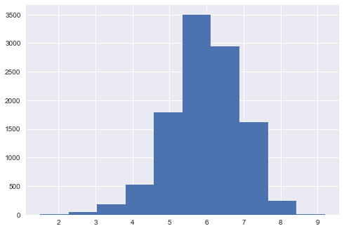

```python
plt.hist(movies['vote_average'])
plt.show()
```

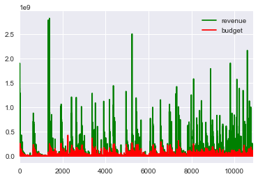

```python
# reveune & budget average
movies.revenue.plot(color='g')
movies.budget.plot(color='r')
plt.legend()
plt.show()
# 1000000000 - 1e9 is one billion -
```

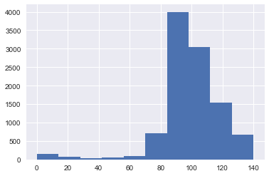

```python
plt.hist(movies['runtime'],range=(0,140),bins=10)
plt.show()
```

#### How many production companies cooperate to create a movie?

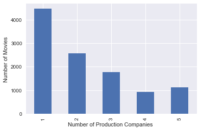

```python
# A lazy way to display a visulization without wrangling the data
movies['production_companies'].apply(lambda x: str.count(x, "|")).value_counts(sort=False).plot(kind='bar')
# again, not the best way :)
plt.xticks([0,1,2,3,4], ['1','2','3','4','5'])
plt.xlabel('Number of Production Companies ')
plt.ylabel('Number of Movies ')
```

#### How many casts per movie?

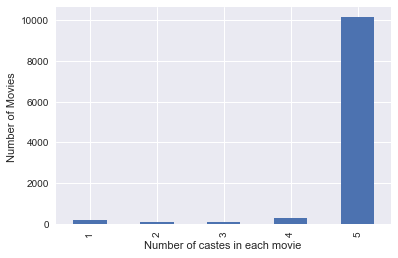

```python
movies['cast'].apply(lambda x: str.count(x, "|")).value_counts(sort=False).plot(kind='bar')
plt.xticks([0,1,2,3,4], ['1','2','3','4','5'])
plt.xlabel('Number of castes in each movie ')
plt.ylabel('Number of Movies ')
```

As I expected, having multiple casts is the common trend in this dataset. I am not sure if I have seen a movie where the cast was only comprised of a single actor. I bet that would be interesting!

#### How many directors per movie?

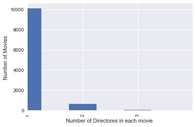

```python
movies['director'].apply(lambda x: str.count(x, "|")).value_counts(sort=True).plot(kind='bar')
plt.xticks([0,1,2], ['1','2','3'])
# I wanted to elimnate anomalies
plt.xlim(0,3)
plt.xlabel('Number of Directores in each movie ')
plt.ylabel('Number of Movies ')
```

Well, I guess we see more of the "I am the director, this is my movie" kind of pattern and I personally understand that direction is where you need someone to lead the cast and have a vision for the movie.

## Exploratory Data Analysis

### What things affect the revenue?

Here, we will start with the things that affect the revenue of movies with revenue being a dependent variable, along with a couple of other independent variables.

#### Budget and revenue? Is there a relationship?

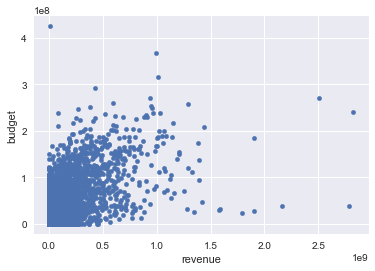

```python
movies.plot(x='revenue', y='budget', kind='scatter');
```

Here, we are checking if there's a positive relationship between budget and revenue. As we can see, there's indeed a positive relationship. Let's not forgot that there's a lot of missing values. I tried to fill in the null values (“0”) with the mean of each column, but the figure didn't change. Maybe if we had more values, it would have been clearer for us. So, it's not possible to come to a strong conclusion that a linear relationship exists between the budget and the revenue. Let’s double check it using **Pearson's R**.

```python
np.corrcoef(movies['revenue'], movies['budget'])
```

```
array([[ 1.        ,  0.64660744],
       [ 0.64660744,  1.        ]])
```

#### What theabout vote average and revenue?

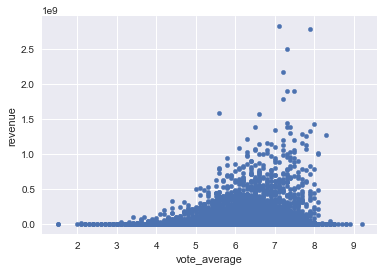

```python
movies.plot(x='vote_average', y='revenue', kind='scatter')
```

Here, we see a trend where the higher the vote average obtained, the more likely it was to get a higher revenue.

#### What about popularity and revenue?

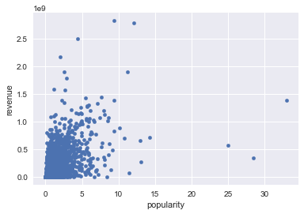

```python
movies.plot(x='popularity', y='revenue', kind='scatter')
```

Those two variables don't seems to be related to one another.

### Who wants to know more about casts?

I wanted to focus on the casts to exlpore two main questions:

- What is the average occurrence in this dataset per director and non-director
- How many of these casts are directors as well?

Let's answer those questions!

#### Average occurrence in this dataset per director and non-director

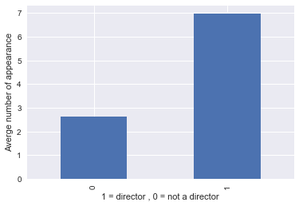

```python
actors.groupby('director').occurrence.mean().plot(kind='bar')
plt.xlabel('1 = director , 0 = not a director')
plt.ylabel('Averge number of appearance')
```

As we can see within this dataset, being a director will increase your chances of appearing in the movies, or it could be interpreted as directors were actors in a lot of movies and then eventually they became a directors? I don't know.

#### How many of these casts are directors as well?

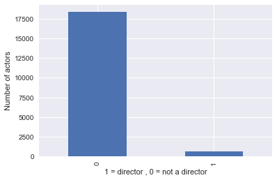

```python
actors.director.value_counts(sort=True).plot(kind='bar')
plt.xlabel('1 = director , 0 = not a director')
plt.ylabel('Number of actors')
```

This graph depicts the number of actors and directors we have on this dataset. I bet there's a much better way to visualize it in order to read the number of directors.

## Conclusion

The movie dataset has endless ways of interpretation. However, missing values for important variables like budget and revenue makes it hard to get an insight. It gives us an insight into the direction that needs to be explored in the future.

We saw that, on average, movies were profitable (keep in mind the missing values). The text information in this data is very rich, as we saw in the case of the casts. It would make a strong case for a machine learning case study. An interesting direction I would like to pursue is the relation between movie revenues and the casts/directors.

Finally, the analysis that was performed shows "an example" of what can be done with such a dataset.